# R Code for Covid top 6 Countries

Indranil and Subhanil

02/09/2020

This code is to prepare and analyze the Covid-19 cases in the world. Specifically, this code will generate the progression of the disease in the top 6 countries, according to number of latest confirmed Covid cases. We will undertake a step by step formulation of how to do it.

First we need to import the libraries required for running the code.

```r
library(tidyverse)
library(ggthemes)
library(zoo)
library(gtable)
library(grid)
library(gridExtra)
library(egg)
```

Once we have called the libraries, we need to get the date for the analysis. This is obtained from the website, www.ourworldindata.org directly through the following command. When the code is run successfully, the data will be seen in the global environment as a dataframe named ‘datacovid’.

```r
datacovid <- read.csv("https://covid.ourworldindata.org/data/owid-covid-data.csv")
```

After we get the data, we can see the variables through the following set of code.

```r
str(datacovid)
```

```
## 'data.frame':    40959 obs. of  40 variables:
##  $ iso_code                       : chr  "AFG" "AFG" "AFG" "AFG" ...
##  $ continent                      : chr  "Asia" "Asia" "Asia" "Asia" ...
##  $ location                       : chr  "Afghanistan" "Afghanistan" "Afghanistan" "Afghanistan" ...
##  $ date                           : chr  "2019-12-31" "2020-01-01" "2020-01-02" "2020-01-03" ...
##  $ total_cases                    : num  0 0 0 0 0 0 0 0 0 0 ...
##  $ new_cases                      : num  0 0 0 0 0 0 0 0 0 0 ...
##  $ new_cases_smoothed             : num  NA NA NA NA NA NA 0 0 0 0 ...
##  $ total_deaths                   : num  0 0 0 0 0 0 0 0 0 0 ...
##  $ new_deaths                     : num  0 0 0 0 0 0 0 0 0 0 ...
##  $ new_deaths_smoothed            : num  NA NA NA NA NA NA 0 0 0 0 ...
##  $ total_cases_per_million        : num  0 0 0 0 0 0 0 0 0 0 ...
##  $ new_cases_per_million          : num  0 0 0 0 0 0 0 0 0 0 ...
##  $ new_cases_smoothed_per_million : num  NA NA NA NA NA NA 0 0 0 0 ...
##  $ total_deaths_per_million       : num  0 0 0 0 0 0 0 0 0 0 ...
```

[output cut: 26 more lines]

It is seen from above that the class of the Date variable is not according to our desired format. Therefore, we convert that variable into a Date using the as.Date command. Additionally, we need to know the latest date for which the data is available. We assign the latest date to a variable d with the max command run on the date variable.

```r
datacovid$date <- as.Date(datacovid$date)

d <-max(datacovid$date)
```

Now, we need to identify the countries having the largest number of infections. For this, we run two sets of codes. Firstly, we filter the data for the latest date and group the data into countries (iso_code variable) and get the number of cases in the latest date. The code is as follows:

```r
df1 <- datacovid %>% filter(date== max(datacovid$date) ) %>%
  group_by(iso_code, total_cases) %>%
  summarise()
```

The df1 dataframe has the countries and the total number of cases for the latest date. But we need to arrange the countries in a descending order of cases. This is done through the following codes.

```r
df1 <- df1[order(df1$total_cases, decreasing = T),]
df1
```

```
## # A tibble: 210 x 2
## # Groups:   iso_code [210]
##    iso_code total_cases
##    <chr>          <dbl>
##  1 OWID_WRL    25509135
##  2 USA          6031013
##  3 BRA          3908272
##  4 IND          3691166
##  5 RUS           995319
##  6 PER           652037
##  7 ZAF           627041
##  8 COL           615168
##  9 MEX           599560
## 10 CHL           411726
## # ... with 200 more rows
```

When we execute the code, we have a problem. World as a whole becomes the number 1 country, because it obviously has the maximum number of cases. So we need to get rid of the iso_code labeled World and extract the top 6 countries by using the [] operator and assign in to a vector named top_6. The code is as follows:

```r
df1 <- df1[-1,]
top_6 <- as.character(df1[1:6,]$iso_code)
```

Now we have the names of the top 6 countries according to Covid cases. We now will now draw plots of these countries together. For that we create a function which does three things: 1) Select the relevant variables, 2) filter the date for cases>50 and 3) calculate the 7 day moving average. The code for the function is given below.

```r
country <- function(df){
  df_country <- datacovid %>%
    select(iso_code, location, date, new_cases, total_cases) %>%
    filter(iso_code ==df, new_cases>=50) %>%
    mutate(mov_avg=rollmean(new_cases, 7, fill = NA, align = "right"))
  assign(df, df_country)}
```

Now, with this function, we will create a list which will include the relevant date for the top 6 countries. The code is as follows:

```r
df_list <- map(top_6, country )
```

Now we need to create another function which will create the relevant plots. For this we use the ggplot2 function.

```r
gr <- function(df){ggplot(data = df, aes(date, new_cases))+
                  geom_col(fill = "Blue", colour = "black") +
                  geom_line(aes(date, mov_avg), data = df, colour="red",size=1)+
                  xlab(NULL) + ylab(NULL) + theme_bw()+
                  ggtitle(df[1,2])}
```

With this gr function we create another list of plots by using the map function.

```r
plots <- map(df_list, gr)
```

The list named ‘plots’ now contains all the six necessary graphs that we want to construct. What remains is to plot them all in a single page. Here library grid and gridextra comes handy along with the command grid.arrange . The code is given below.

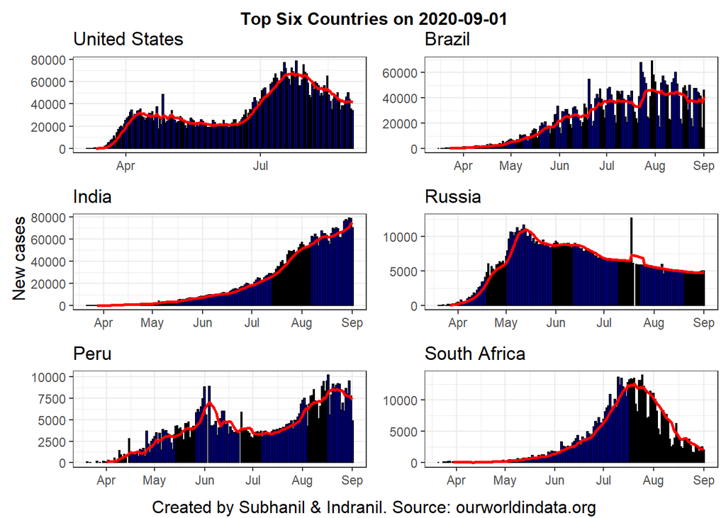

```r
grid.newpage()

grid.arrange(grobs = plots,
             top = textGrob(paste("Top Six Countries on", d, sep = " "), vjust = 1, gp = gpar(fontface = "bold", cex = 1.0)),
             left = textGrob("New cases", rot = 90, vjust = 1),
             bottom = textGrob("Created by Subhanil & Indranil. Source: ourworldindata.org"))
```

Obviously, many more operations can be done as per your requirements. This was just an illustration!

Happy Coding!